# GEOG 176A: Intro to GIS

Lab 02: COVID-19 Pandemic

[Ian Hinds](https://hindstein.github.io/GEOG176A/)

## Libraries

- *tidyverse*
- *knitr*
- *readxl*
- *zoo*

## COVID Data URL (NYTimes)

https://raw.githubusercontent.com/nytimes/covid-19-data/master/us-counties.csv

## Population Data (USDA)

https://www.ers.usda.gov/webdocs/DataFiles/48747/PopulationEstimates.xls?v=2561.3

## Question 1

As it stands, the California Department of Public Health maintains a watch list of counties that are being monitored for worsening coronavirus trends. There are six criteria used to place counties on the watch list:

- Doing fewer than 150 tests per 100,000 residents daily (over a 7-day average)
- More than 100 new cases per 100,000 residents over the past 14 days…
- 25 new cases per 100,000 residents and an 8% test positivity rate
- 10% or greater increase in COVID-19 hospitalized patients over the past 3 days
- Fewer than 20% of ICU beds available
- Fewer than 25% ventilators available

**Of these 6 conditions, we will monitor condition number 2.**

To do this job well, you should set up a reproducible framework to communicate the following in a way that can be updated every time new data is released:

**Cumulative cases in the 5 worst counties to date:**

Counties with the Most Cases

| County | Cases |
| --- | --- |
| Los Angeles | 221950 |
| Riverside | 46720 |
| Orange | 43709 |
| San Bernardino | 41231 |
| San Diego | 34741 |

**Total NEW cases in the 5 Worst Counties Today**

New Cases

| County | Cases |
| --- | --- |
| Los Angeles | 1188 |
| San Bernardino | 789 |
| Fresno | 703 |
| Sacramento | 373 |
| Orange | 342 |

## Question 2

In this question, we are going to look at the story of 4 states and the impact scale can have on data interprtation. The states include: New York, California, Louisiana, and Florida.

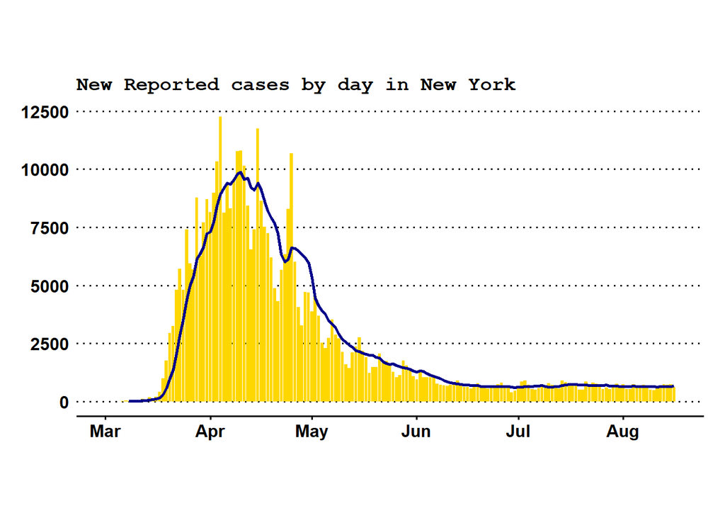

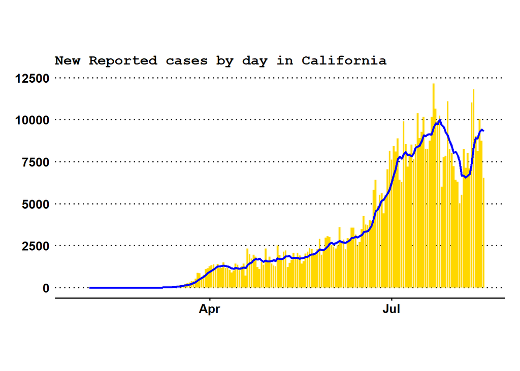

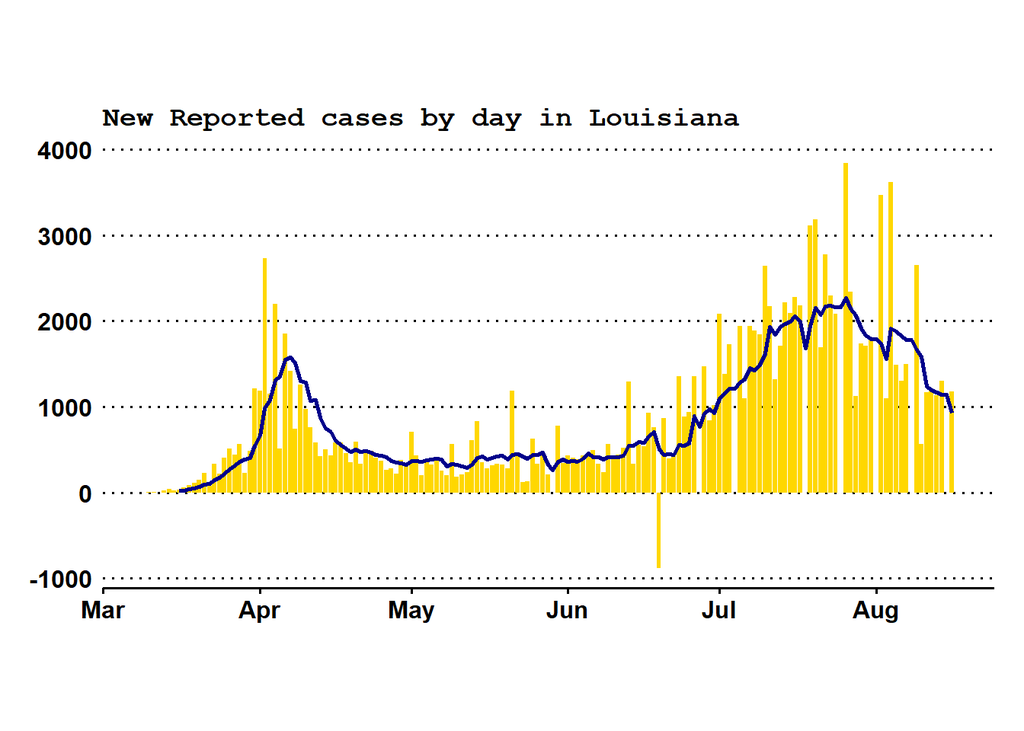

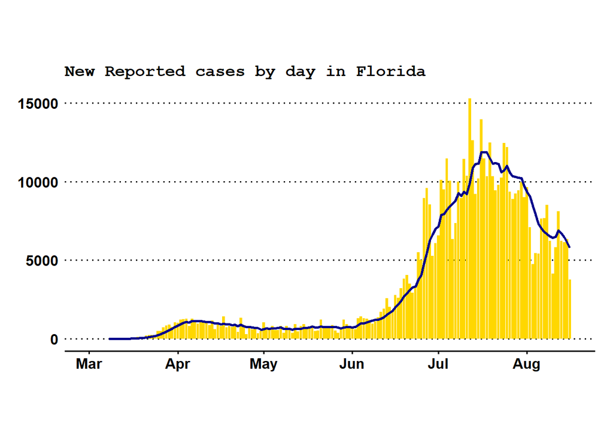

> Conclusion: States with higher populations represented larger spikes in daily cases. These states are Florida, California, and New York. Louisiana, containing a much smaller populous, experiences a less extreme variance in case frequency. Scaling by population would make the larger populations look more similar, and the smaller populations more different.

## Question 3:

> Metropolitan environments and other largely populated areas throughout the U.S. have seen drastic spikes in case numbers in a short time span. The inconsistent practice of wearing a mask and social distancing has negativvely affected some communites, especially those who are at risk of being a hot spot. COVID-19 can spread easiest when physical and close contact is exchanged with individuals, therefore larger communities have seen the greatest number of cases.